← Voltar ao Portal

[figure not shown]

Programa 403

# Síntese Avaliativa do Desempenho dos Programas do PPA Bahia 2024–2027

# **1 - Desempenho Global do Programa**

Este documento apresenta uma Síntese Avaliativa do Desempenho do Programa do Plano Plurianual - PPA 2024- 2027, trazendo uma visão estratégica dos seus resultados, de forma sintética, transparente e colaborativa. Serão levados em consideração o Indicador Sintético de Desempenho do Programa (ISDP), a evolução dos Indicadores de Programa, a eficácia das metas dos Indicadores de Compromisso, o desempenho da execução orçamentária-financeira e da execução física das Ações orçamentárias. O ISDP é uma síntese dessas quatro dimensões, destacando o desempenho do programa em relação aos resultados obtidos e aos esforços despendidos.  
Adicionalmente, são apresentados os principais resultados alcançados, evidenciando os avanços e conformidades dos cinco programas com melhores resultados, além das oportunidades de melhoria dos cinco, com menores resultados. Enquanto neste documento a análise abrange o programa e seus componentes de maneira sintética, nos demais relatórios, a análise detalhada evidencia o comportamento dos componentes do PPA por programas e por órgãos (https://www.ba.gov.br/seplan/monitoramento-e-avaliacao/avaliacao-do-ppa). Além desta Síntese, o [Painel BI - Boletim de Avanços e Oportunidades de Melhoria](https://app.powerbi.com/view?r=eyJrIjoiN2Q0ODliNDItZDFjZi00MGM1LTliNGEtODVmZDAwZTQ1OGEyIiwidCI6IjRjZDgzNWY0LTU0NDAtNDA4Zi05M2EzLTk3NWZjMTdjMzg0YSIsImMiOjR9) oferece informações organizadas em uma perspectiva estratégica do desempenho consolidado dos programas, detalhando, no entanto, cada componente avaliado. A análise nesta seção engloba o programa e seus componentes conforme segue:

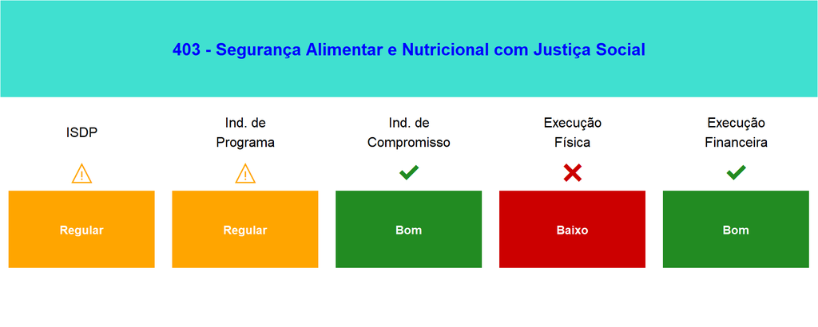

# **2 - Avanços e Conformidades no Programa**

**Indicadores de Programa:** No programa 403 - Segurança Alimentar e Nutricional com Justiça Social, 60% dos indicadores mostraram evolução positiva. O indicador 2176, que mede o percentual de crianças até 2 anos com baixo peso, apresentou uma evolução de -30,66%. Essa melhora é resultado da expansão das iniciativas da Superintendência em novos municípios, o que levou a um aumento significativo no número de beneficiados e, consequentemente, à redução do índice de crianças com peso abaixo do recomendado. Além disso, o indicador 2174, que avalia a proporção de adultos com baixo peso, teve uma evolução de -19,57%, refletindo melhores escolhas alimentares e o impacto das políticas públicas voltadas para a redução da insegurança alimentar.  
**Indicadores de Compromisso:** No programa 403 - Segurança Alimentar e Nutricional com Justiça Social, 53% dos indicadores de compromisso foram classificados como tendo desempenho bom ou ótimo. Destaca-se o indicador ‘2 - Número de municípios aderidos que receberam apoio operacional para o Sistema de Segurança Alimentar e Nutricional – SISAN’, que alcançou 110,47%. Esse resultado é atribuível à incidência de demandas não inicialmente previstas, especialmente devido às ações da SISA e Bahia Sem Fome, além do apoio do CONSEA/BA, que ofereceram suporte técnico e institucional às gestões municipais, facilitando a criação de conselhos, planos e estruturas necessárias para a adesão ao SISAN. Essa estratégia ativa de mobilização despertou o interesse das prefeituras, acelerando o processo de adesão. Outro indicador relevante é o ‘1 - Número de municípios com adesão ao Sistema Nacional de Segurança Alimentar e Nutricional - SISAN’, que também alcançou 110,47%, resultado das oportunidades, parcerias e adesões que viabilizaram a realização das ações mencionadas.  
**Ações Orçamentárias:** Em relação ao Programa 403 - Segurança Alimentar e Nutricional com Justiça Social, 90% das ações foram classificadas como de bom ou ótimo desempenho na execução financeira; no entanto, apenas 25% atingiram essa classificação na execução física. Destacam-se, nesse contexto, a Ação 4096 - Assistência Técnica para Qualificação de Empreendedor Individual e Familiar, que apresentou execuções financeiras e físicas classificadas como Ótimas, assim como a Ação 4409 - Fornecimento de Refeição Balanceada, que também obteve classificações semelhantes.

# **3 - Oportunidade de Melhoria no Programa**

**Indicadores de Programa:** Em contrapartida, no Programa 403 - Segurança Alimentar e Nutricional com Justiça Social, 40% dos indicadores apresentaram evolução negativa. O indicador 2175, que mede a proporção de adultos com obesidade, registrou um aumento de 17,08%. Esse crescimento pode ser parcialmente explicado pela ampliação das ações da Superintendência em novas regiões, resultando em uma maior identificação do perfil nutricional da população. Fatores como escolhas alimentares inadequadas, a diminuição da prática de atividades físicas e as dificuldades no acompanhamento de doenças crônicas também contribuem para esse aumento.  
**Indicadores de Compromisso:** No programa 403 - Segurança Alimentar e Nutricional com Justiça Social, 11,8% dos indicadores foram classificados como desempenho baixo ou muito baixo e 17,6% como indeterminado. O indicador ‘3 - Número de empreendimentos apoiados’, crucial para a Política de Inclusão e Segurança Alimentar, não conseguiu alcançar resultados, atingindo 0%. Isso ocorreu devido à revisão das estratégias de capacitação, que não geraram ações durante o ano. Por outro lado, o indicador ‘1 - Número de tecnologias sociais de captação de água’ alcançou performance de 31,03%, como resultado de novos contratos e edital que possibilitaram a entrega de tecnologias de captação, contribuindo para o acesso à água.  
**Ações Orçamentárias:** No entanto, no Programa 403 - Segurança Alimentar e Nutricional com Justiça Social, 10% das ações foram avaliadas como de baixo ou muito baixo desempenho na execução financeira. Na execução física, essa situação se agrava, com 75% das ações sendo classificadas como baixo ou muito baixo. Um exemplo relevante é a ação 7148 - Implantação de Tecnologia Social, que teve execução financeira classificada como “Baixo” e física como “Muito Baixo”.

Desenvolvido por: DAP – Diretoria de Avaliação de Políticas Públicas